# Final model evaluation

This is the final notebook of the speed of sound prediction experiment. It tests final models using three different tests.

- General test
- Inside matrix test
- Outside matrix test

```python
# dependecies

import pandas as pd
import numpy as np
import matplotlib as mpl
import matplotlib.pyplot as plt

%matplotlib inline
```

**Restore the splitted data**

```python
%store -r X_train
%store -r y_train
```

```python
%store -r X_val
%store -r y_val
```

```python
%store -r X_test
%store -r y_test
```

**Merge training and validation data for general test on test data**

```python
X = pd.concat([X_train, X_val])
y = np.concatenate((y_train, y_val))
```

**Metrics funtion**

```python
# r2 and rmse and AARD returning function
from sklearn.metrics import r2_score, mean_squared_error

def result_stats(actual, predicted):
    """
    Returns r_2, rmse and AARD value for two arrays of equal length
    """

    r2 = r2_score(actual, predicted)
    rmse = np.sqrt(mean_squared_error( actual, predicted ))
    aard = (100 / len(actual)) * np.sum(np.abs((actual - predicted) / actual))

    return r2,rmse, aard
```

**Restore optimal hyperparameters, feature sets for SVM and random forest models**

```python
%store -r svm_params
%store -r svm_features
```

```python
%store -r rf_params
# the random forest has optimized max_features hyperparameter
# it is therefore trained on full feature set
```

**Import the models**

```python
from sklearn.svm import SVR as SVM
svm = SVM(gamma = "auto", **svm_params)    # gamma value is left at default; explicitly set to surpress warnings
```

```python
from sklearn.ensemble import RandomForestRegressor as RF
rf = RF(n_estimators = 20, **rf_params)    # use 20 estimators
```

## General test

This it the test the models were optimized for.

- Train: development data (training + validation data)
- Test: test data

**Plotting function**

```python
def general_test_plot(model_pred):
    """
    This function plots the residuals against both temperature and molality.
    It also plots predicted vs experimental values.
    Input: model predictions
    """

    # create figure for three graphs
    fig, ax = plt.subplots(ncols = 3, nrows = 1, figsize = (20, 5))


    # Residual plot against normalized temperature
    ax[0].scatter(x=X_test["T"], y=model_pred - y_test, s =0.5, c="r")
    ax[0].set_xlabel("$T$")
    ax[0].set_title("Residual plot against normalized temperature")
    ax[0].set_ylabel("$u$ [m/s]")

    # Residual plot against normalized molality
    ax[1].scatter(x=X_test["c"], y=model_pred - y_test, s =0.5, c="r")
    ax[1].set_xlabel("$c$")
    ax[1].set_title("Residual plot against normalized molality")
    ax[1].set_ylabel("$u$ [m/s]")

    # Predicted vs experimental values
    ax[2].scatter(y=y_test, x=model_pred, s =0.8, c ="r")
    ax[2].set_xlabel("Predicted $u$ [m/s]")
    ax[2].set_title("Predicted vs experimental values")
    ax[2].set_ylabel("Experimental $u$ [m/s]")

    # plot 0 residual line
    ax[2].set_ylim(ax[2].get_ylim()[0],ax[2].get_ylim()[1])
    ax[2].set_xlim(ax[2].get_xlim()[0],ax[2].get_xlim()[1])
    ax[2].plot([1000, 2000], [1000, 2000], linewidth = 0.2, c = "k")
```

### SVM regressor

**RMSE**

```python
# fit on development data, test on test set
# use correct feature set
svm.fit(X[svm_features], y)
svm_pred = svm.predict(X_test[svm_features])
print("General test RMSE for SVM model: RMSE {0:.2f}".format(result_stats(svm_pred,y_test)[1]))
```

```
General test RMSE for SVM model: RMSE 3.36
```

**Result plots**

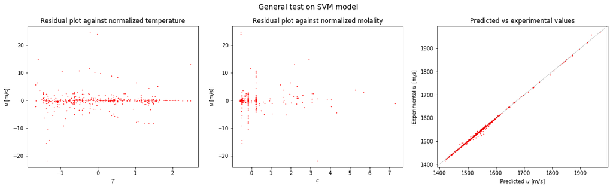

```python
general_test_plot(svm_pred)

# get current figure to add correct figure title
fig = plt.gcf()
fig.suptitle("General test on SVM model", x = 0.5, y = 1, size = 14)
plt.show()
```

### Random forest regressor

**RMSE**

```python
# fit on development data, test on test set
rf.fit(X, y)
rf_pred = rf.predict(X_test)
print("General test RMSE for random forest model: RMSE {0:.2f}".format(result_stats(rf_pred,y_test)[1]))
```

```
General test RMSE for random forest model: RMSE 7.02
```

**Result plots**

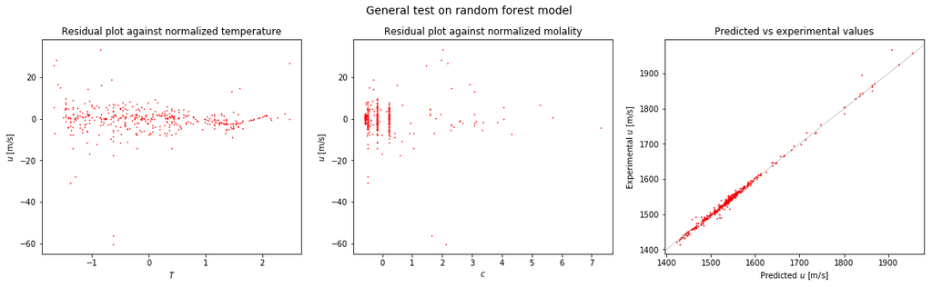

```python
general_test_plot(rf_pred)

# get current figure to add correct figure title
fig = plt.gcf()
fig.suptitle("General test on random forest model", x = 0.5, y = 1, size = 14)
plt.show()
```

## Inside matrix test

This test tests how well the models can predict data for an electrolyte not present in training data.  
For each medium a graph of both predicted (red) and actual (black) speed of sound values against temperature is plotted.

- Train: data on all but one electrolyte
- Test: the remaining electrolyte data

```python
# load dataset with all the preprocessed data
# the original temperature values are stored in T_orig feature
df = pd.read_csv("../datasets/preprocessed.csv", index_col = 0)
```

```python
df.head()
```

|  | T | c | a_es | a_r | a_dr | a_hn | a_ge | a_gh | a_mw | a_q | ... | c_mw | c_pK | moles | Z | Kw | cm | is | medium | sound | T_orig |
| --- | --- | --- | --- | --- | --- | --- | --- | --- | --- | --- | --- | --- | --- | --- | --- | --- | --- | --- | --- | --- | --- |
| 638 | -0.982685 | -0.431494 | -0.607 | -1.000000 | 1.000000 | 1.708035e-16 | 0.715789 | 0.701923 | -1.000000 | -1.0 | ... | -0.862998 | -0.622535 | -1.0 | -0.895116 | -0.996980 | -0.440781 | -0.406215 | LiOH | 1494.200 | 289.75 |
| 699 | -0.757805 | -0.497466 | -0.312 | 0.658120 | -0.200000 | 3.076923e-01 | -0.610526 | -0.548077 | 0.438729 | 1.0 | ... | -0.492403 | -0.464789 | 0.0 | -0.045874 | -0.736256 | -0.588643 | -0.344312 | Na2SO4 | 1504.660 | 295.15 |
| 1022 | 0.283310 | -0.497466 | 0.966 | -0.213675 | -0.166667 | -5.384615e-01 | 0.848421 | 0.951923 | -0.181088 | -1.0 | ... | -0.492403 | -0.464789 | -1.0 | -0.261363 | 0.356364 | -0.588643 | -0.450913 | NaNO3 | 1541.900 | 320.15 |
| 855 | -0.008202 | -0.497466 | -0.932 | -0.230769 | 0.900000 | 1.000000e+00 | -1.000000 | -1.000000 | -0.217413 | 1.0 | ... | -0.492403 | -0.464789 | 0.0 | -0.275704 | 0.067988 | -0.588643 | -0.344312 | Na2CO3 | 1544.190 | 313.15 |
| 412 | -0.249741 | -0.576134 | -0.607 | -1.000000 | 1.000000 | 1.708035e-16 | 0.715789 | 0.701923 | -1.000000 | -1.0 | ... | -1.000000 | -1.000000 | -1.0 | -1.000000 | -0.180888 | -0.883892 | -0.504213 | HOH | 1518.212 | 307.35 |

5 rows × 27 columns

```python
# get the list of all available electrolytes
mediums = df["medium"].unique()
```

### Run the inside matrix test for each electrolyte

The inside_matrix_test function defined below plots the graph of inside matrix test for each electrolyte. The RMSE error is noted in the graph's title.

```python
def inside_matrix_test(model, features):
    """
    This function plots actual and predicted speed of sound values for all mediums in df.
    df is the dataframe with all data.
    The predictions are trained on input model with input feature set.
    """
    for medium in mediums:
        # form the test/train sets
        df_test = df[df["medium"] == medium]
        df_train = df[df["medium"] != medium]

        model.fit(df_train[features],df_train["sound"])
        model_pred = model.predict(df_test[features])
        _, r, _ = result_stats(model_pred,df_test["sound"])

        # plot predictions red
        plt.scatter(x=df_test["T_orig"], y=model_pred, s =0.5, c = "r")
        # plot actual values black
        plt.scatter(x=df_test["T_orig"], y=df_test["sound"], s =0.5, c="k")

        plt.xlabel("$T$ [K]")
        plt.title("Predicted vs real speed of sound values of {0}. RMSE: {1:.1f}".format(medium, r))
        plt.ylabel("$u$ [m/s]")

        plt.show()
```

### SVM regressor

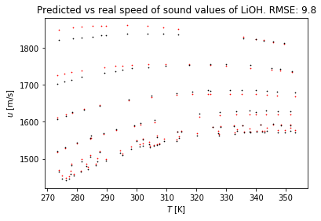

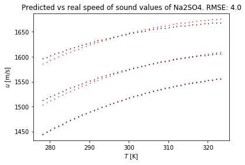

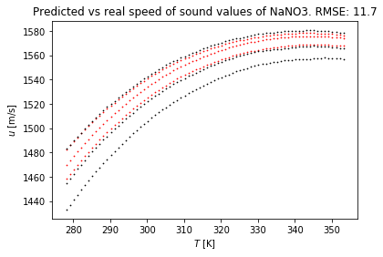

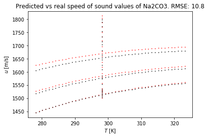

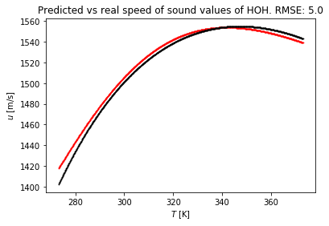

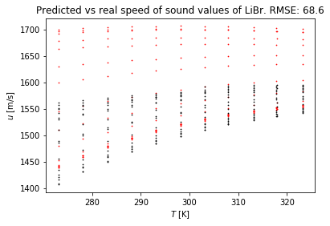

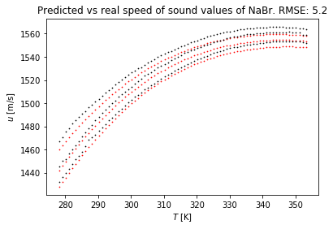

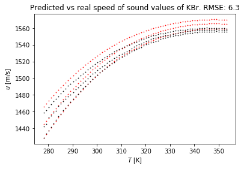

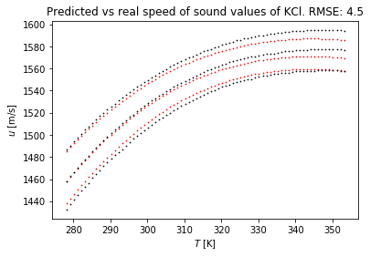

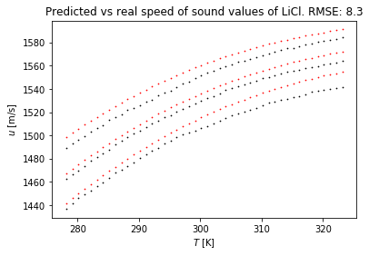

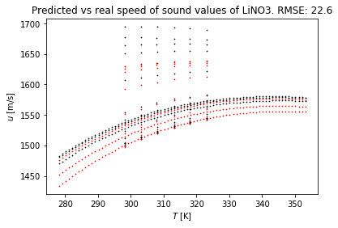

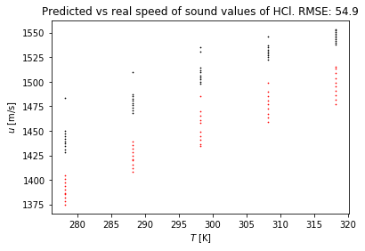

[15 more figures not shown]

```python
inside_matrix_test(svm, svm_features)
```

### Random forest regressor

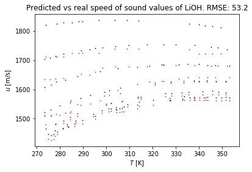

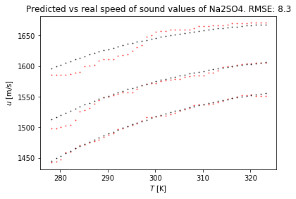

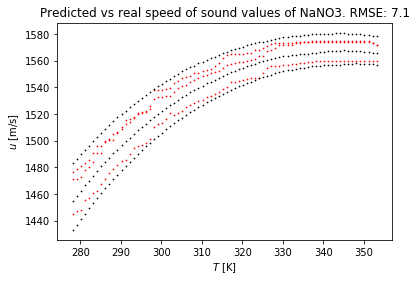

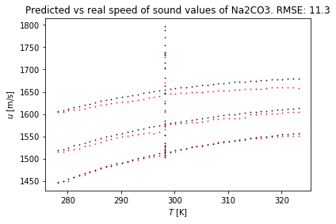

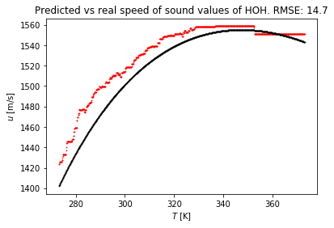

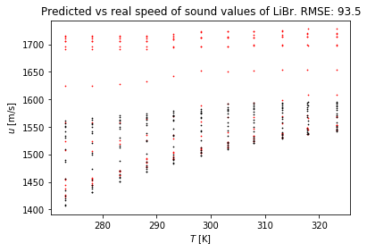

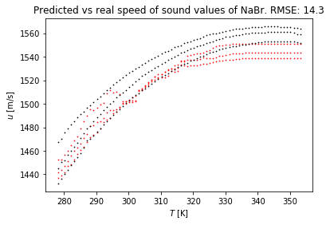

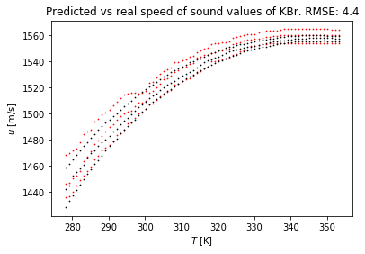

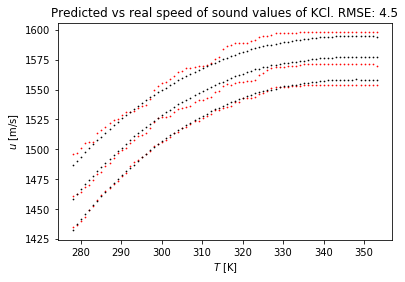

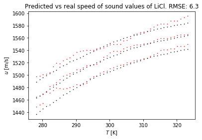

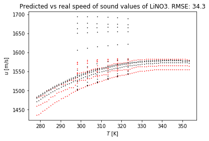

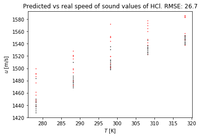

[15 more figures not shown]

```python
inside_matrix_test(rf, list(X.columns))
```

### List of all inside matrix test results

```python
for medium in mediums:

    df_test = df[df["medium"] == medium]
    df_train = df[df["medium"] != medium]

    # svm predictions
    svm.fit(df_train[svm_features],df_train["sound"])
    svm_pred = svm.predict(df_test[svm_features])
    _, r_svm , _ = result_stats(svm_pred,df_test["sound"])

    # rf predictions
    rf.fit(df_train[list(X.columns)],df_train["sound"])
    rf_pred = rf.predict(df_test[list(X.columns)])
    _, r_rf , _ = result_stats(rf_pred,df_test["sound"])

    print("{0:10} SVM RMSE {1:5.1f}; RF RMSE {2:5.1f}".format(medium, r_svm, r_rf))
```

```
LiOH       SVM RMSE   9.8; RF RMSE  48.2
Na2SO4     SVM RMSE   4.0; RF RMSE   6.2
NaNO3      SVM RMSE  11.7; RF RMSE   7.9
Na2CO3     SVM RMSE  10.8; RF RMSE   9.6
HOH        SVM RMSE   5.0; RF RMSE  12.9
LiBr       SVM RMSE  68.6; RF RMSE 100.7
NaBr       SVM RMSE   5.2; RF RMSE  15.7
KBr        SVM RMSE   6.3; RF RMSE   4.3
KCl        SVM RMSE   4.5; RF RMSE   4.6
LiCl       SVM RMSE   8.3; RF RMSE   6.5
LiNO3      SVM RMSE  22.6; RF RMSE  35.3
HCl        SVM RMSE  54.9; RF RMSE  24.3
NaOH       SVM RMSE  10.7; RF RMSE 118.7
K2SO4      SVM RMSE   3.5; RF RMSE   7.3
NaCl       SVM RMSE   2.6; RF RMSE   7.7
KNO3       SVM RMSE  13.8; RF RMSE   6.7
KI         SVM RMSE  18.6; RF RMSE  17.6
NaI        SVM RMSE  16.1; RF RMSE  21.4
KOH        SVM RMSE   6.1; RF RMSE  14.9
NH42SO4    SVM RMSE  82.8; RF RMSE 119.5
NH4OH      SVM RMSE 111.3; RF RMSE 179.8
NH4Cl      SVM RMSE  16.1; RF RMSE  10.2
NH4Br      SVM RMSE  13.8; RF RMSE  11.6
K2CO3      SVM RMSE  31.8; RF RMSE  94.5
Li2SO4     SVM RMSE  36.9; RF RMSE  47.0
HNO3       SVM RMSE  54.1; RF RMSE 107.7
NH4NO3     SVM RMSE  24.8; RF RMSE  15.7
```

## Outside matrix test

This test tests how well the models can predict data for an electrolyte having of its ions completely outside the training data.

- Train: all (training + validation + test data)
- Test: additional RbI data

```python
# load the RbI dataset
try:
    outtest = pd.read_csv("../datasets/o_preprocessed.csv", index_col = 0)
except FileNotFoundError:
        print("The creation of o_preprocessed.csv must have been skipped")
```

### SVM regressor

**RMSE**

```python
svm.fit(df[svm_features], df["sound"])
svm_pred = svm.predict(outtest[svm_features])
print("Outside matrix test RMSE for SVM model: RMSE {0:.2f}".format(result_stats(svm_pred,outtest["sound"])[1]))
```

```
Outside matrix test RMSE for SVM model: RMSE 51.47
```

**Plot of predicted (red) and experimental (black) sound speeds**

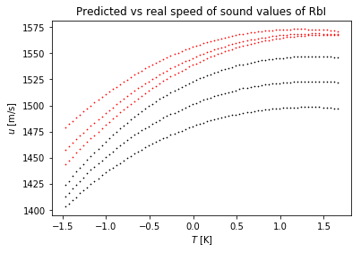

```python
plt.scatter(x=outtest["T"], y=svm_pred, marker = "o", s =0.5, c = "r")
plt.scatter(x=outtest["T"], y=outtest["sound"], s =0.5, c="k", marker = 'x')

plt.xlabel("$T$ [K]")
plt.title("Predicted vs real speed of sound values of RbI")
plt.ylabel("$u$ [m/s]")

plt.show()
```

### Random forest regressor

**RMSE**

```python
rf.fit(df[list(X.columns)], df["sound"])
rf_pred = rf.predict(outtest[list(X.columns)])
print("Outside matrix test RMSE for random forest model: RMSE {0:.2f}".format(result_stats(rf_pred,outtest["sound"])[1]))
```

```
Outside matrix test RMSE for random forest model: RMSE 37.26
```

**Plot of predicted (red) and experimental (black) sound speeds**

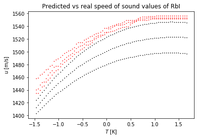

```python
plt.scatter(x=outtest["T"], y=rf_pred, marker = "o", s =0.5, c = "r")
plt.scatter(x=outtest["T"], y=outtest["sound"], s =0.5, c="k", marker = 'x')

plt.xlabel("$T$ [K]")
plt.title("Predicted vs real speed of sound values of RbI")
plt.ylabel("$u$ [m/s]")

plt.show()
```

### Variation on outside matrix test

**This is not discussed in the thesis**  
Variation on the outside matrix test was carried out by removing all data for a fixed cation or anion from the original electrolytes. This test was carried for each ion.

- Train: All data, except for all data for a given ion
- Test: All data for the removed ion

**Define all ions**

```python
# lists storing used ionic species

cations = ["Na", "K", "Li", "NH4", "H"]
anions = ["Br","Cl", "I", "2SO4", "2CO3", "NO3", "OH"]
```

**Outside matrix test for specific cation**

```python
for c in cations:
    # put data for cation c into test set
    df_test = df[df["medium"].apply(lambda x: x.startswith(c))]
    df_train = df[df["medium"].apply(lambda x: not x.startswith(c))]

    # svm predictions
    svm.fit(df_train[svm_features],df_train["sound"])
    svm_pred = svm.predict(df_test[svm_features])
    _, r_svm , _ = result_stats(svm_pred,df_test["sound"])

    # rf predictions
    rf.fit(df_train[list(X.columns)],df_train["sound"])
    rf_pred = rf.predict(df_test[list(X.columns)])
    _, r_rf , _ = result_stats(rf_pred,df_test["sound"])

    print("{0}: SVM RMSE {1:.1f}; RF RMSE {2:.1f}".format(c, r_svm, r_rf))
```

```
Na: SVM RMSE 11.1; RF RMSE 41.5
K: SVM RMSE 14.7; RF RMSE 40.7
Li: SVM RMSE 54.6; RF RMSE 106.8
NH4: SVM RMSE 93.4; RF RMSE 122.1
H: SVM RMSE 18.6; RF RMSE 21.1
```

**Outside matrix test for specific anion**

```python
for a in anions:
    # put data for anion a into test set
    df_test = df[df["medium"].apply(lambda x: x.endswith(a))]
    df_train = df[df["medium"].apply(lambda x: not x.endswith(a))]

    # svm predictions
    svm.fit(df_train[svm_features],df_train["sound"])
    svm_pred = svm.predict(df_test[svm_features])
    _, r_svm , _ = result_stats(svm_pred,df_test["sound"])

    # rf predictions
    rf.fit(df_train[list(X.columns)],df_train["sound"])
    rf_pred = rf.predict(df_test[list(X.columns)])
    _, r_rf , _ = result_stats(rf_pred,df_test["sound"])

    print("{0}: SVM RMSE {1:.1f}; RF RMSE {2:.1f}".format(a, r_svm, r_rf))
```

```
Br: SVM RMSE 38.3; RF RMSE 47.0
Cl: SVM RMSE 16.6; RF RMSE 14.6
I: SVM RMSE 13.5; RF RMSE 16.2
2SO4: SVM RMSE 58.8; RF RMSE 104.4
2CO3: SVM RMSE 24.2; RF RMSE 45.1
NO3: SVM RMSE 18.6; RF RMSE 20.0
OH: SVM RMSE 52.1; RF RMSE 65.2
```